# ggplot 102: Facets, Scales, Labels, and Themes (but now 🐶) recitation

Jessica Cooperstone and you

9/20/2022

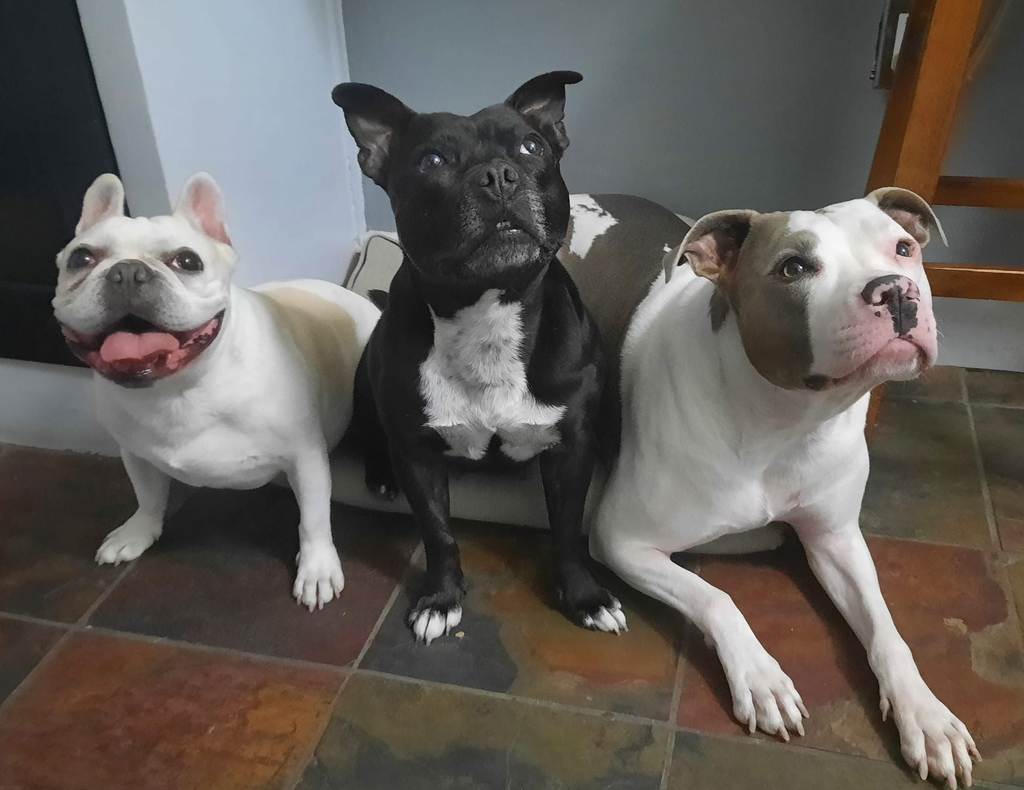

Nacho (Jess’s dog, left) along with his friends Petunia (middle) and Inu (right) waiting for dinner

## Introduction

We will practice what we learned this week in ggplot102 on:

- [Facets](https://ggplot2.tidyverse.org/reference/index.html#facetting)
- [Scales](https://ggplot2.tidyverse.org/reference/index.html#scales)
- [Labels](https://ggplot2.tidyverse.org/reference/index.html#labels)
- [Themes](https://ggplot2.tidyverse.org/reference/index.html#themes)

### Load libraries and data

Before we get started, let’s load our libraries and data. Today we will be looking again at some different data from the [Tidy Tuesday project](https://www.tidytuesday.com/) (here is the [Github repo](https://github.com/rfordatascience/tidytuesday/blob/master/data/2022/2022-02-01/readme.md)) about dog breeds.

```r
install.packages("tidytuesdayR")
```

```r
library(tidyverse)
library(tidytuesdayR)
```

We will be using the data that is from February 1, 2022, so let’s download it. The readme for this data is [here](https://github.com/rfordatascience/tidytuesday/blob/master/data/2022/2022-02-01/readme.md).

```r
tuesdata <- tidytuesdayR::tt_load('2022-02-01')
```

```
## --- Compiling #TidyTuesday Information for 2022-02-01 ----
```

```
## --- There are 3 files available ---
```

```
## --- Starting Download ---
```

```
## --- Download complete ---
```

### Let’s look at it

```r
glimpse(tuesdata)
```

```
## List of 3
##  $ breed_traits     : spec_tbl_df [195 × 17] (S3: spec_tbl_df/tbl_df/tbl/data.frame)
##   ..$ Breed                     : chr [1:195] "Retrievers (Labrador)" "French Bulldogs" "German Shepherd Dogs" "Retrievers (Golden)" ...
##   ..$ Affectionate With Family  : num [1:195] 5 5 5 5 4 5 3 5 5 5 ...
##   ..$ Good With Young Children  : num [1:195] 5 5 5 5 3 5 5 3 5 3 ...
##   ..$ Good With Other Dogs      : num [1:195] 5 4 3 5 3 3 5 3 4 4 ...
##   ..$ Shedding Level            : num [1:195] 4 3 4 4 3 1 3 3 3 2 ...
##   ..$ Coat Grooming Frequency   : num [1:195] 2 1 2 2 3 4 2 1 2 2 ...
##   ..$ Drooling Level            : num [1:195] 2 3 2 2 3 1 1 3 2 2 ...
##   ..$ Coat Type                 : chr [1:195] "Double" "Smooth" "Double" "Double" ...
##   ..$ Coat Length               : chr [1:195] "Short" "Short" "Medium" "Medium" ...
##   ..$ Openness To Strangers     : num [1:195] 5 5 3 5 4 5 3 3 4 4 ...
##   ..$ Playfulness Level         : num [1:195] 5 5 4 4 4 5 4 4 4 4 ...
##   ..$ Watchdog/Protective Nature: num [1:195] 3 3 5 3 3 5 2 5 4 4 ...
##   ..$ Adaptability Level        : num [1:195] 5 5 5 5 3 4 4 4 4 4 ...
##   ..$ Trainability Level        : num [1:195] 5 4 5 5 4 5 3 5 5 4 ...
##   ..$ Energy Level              : num [1:195] 5 3 5 3 3 4 4 3 5 3 ...
##   ..$ Barking Level             : num [1:195] 3 1 3 1 2 4 4 1 3 5 ...
##   ..$ Mental Stimulation Needs  : num [1:195] 4 3 5 4 3 5 4 5 5 3 ...
##   ..- attr(*, "spec")=
##   .. .. cols(
##   .. ..   Breed = col_character(),
##   .. ..   `Affectionate With Family` = col_double(),
##   .. ..   `Good With Young Children` = col_double(),
##   .. ..   `Good With Other Dogs` = col_double(),
##   .. ..   `Shedding Level` = col_double(),
##   .. ..   `Coat Grooming Frequency` = col_double(),
##   .. ..   `Drooling Level` = col_double(),
##   .. ..   `Coat Type` = col_character(),
##   .. ..   `Coat Length` = col_character(),
##   .. ..   `Openness To Strangers` = col_double(),
##   .. ..   `Playfulness Level` = col_double(),
##   .. ..   `Watchdog/Protective Nature` = col_double(),
##   .. ..   `Adaptability Level` = col_double(),
##   .. ..   `Trainability Level` = col_double(),
##   .. ..   `Energy Level` = col_double(),
##   .. ..   `Barking Level` = col_double(),
##   .. ..   `Mental Stimulation Needs` = col_double()
##   .. .. )
##   ..- attr(*, "problems")=<externalptr>
```

[output cut: 36 more lines]

```
##   .. ..   links = col_character(),
##   .. ..   Image = col_character()
##   .. .. )
##   ..- attr(*, "problems")=<externalptr>
##  - attr(*, ".tt")= 'tt' chr [1:3] "breed_traits.csv" "trait_description.csv" "breed_rank.csv"
##   ..- attr(*, ".files")='data.frame':    3 obs. of  3 variables:
##   .. ..$ data_files: chr [1:3] "breed_traits.csv" "trait_description.csv" "breed_rank.csv"
##   .. ..$ data_type : chr [1:3] "csv" "csv" "csv"
##   .. ..$ delim     : chr [1:3] "," "," ","
##   ..- attr(*, ".readme")=List of 2
##   .. ..$ node:<externalptr>
##   .. ..$ doc :<externalptr>
##   .. ..- attr(*, "class")= chr [1:2] "xml_document" "xml_node"
##   ..- attr(*, ".date")= Date[1:1], format: "2022-02-01"
##  - attr(*, "class")= chr "tt_data"
```

Note `tuesdata` is a list of 3 dataframes.

We will use the `$` to see the different dataframes individually.

```r
glimpse(tuesdata$breed_traits)
```

```
## Rows: 195
## Columns: 17
## $ Breed                        <chr> "Retrievers (Labrador)", "French Bulldogs…
## $ `Affectionate With Family`   <dbl> 5, 5, 5, 5, 4, 5, 3, 5, 5, 5, 5, 3, 5, 4,…
## $ `Good With Young Children`   <dbl> 5, 5, 5, 5, 3, 5, 5, 3, 5, 3, 3, 5, 5, 5,…
## $ `Good With Other Dogs`       <dbl> 5, 4, 3, 5, 3, 3, 5, 3, 4, 4, 4, 3, 3, 3,…
## $ `Shedding Level`             <dbl> 4, 3, 4, 4, 3, 1, 3, 3, 3, 2, 4, 3, 1, 2,…
## $ `Coat Grooming Frequency`    <dbl> 2, 1, 2, 2, 3, 4, 2, 1, 2, 2, 2, 2, 5, 2,…
## $ `Drooling Level`             <dbl> 2, 3, 2, 2, 3, 1, 1, 3, 2, 2, 1, 1, 1, 3,…
## $ `Coat Type`                  <chr> "Double", "Smooth", "Double", "Double", "…
## $ `Coat Length`                <chr> "Short", "Short", "Medium", "Medium", "Sh…
## $ `Openness To Strangers`      <dbl> 5, 5, 3, 5, 4, 5, 3, 3, 4, 4, 4, 3, 5, 4,…
## $ `Playfulness Level`          <dbl> 5, 5, 4, 4, 4, 5, 4, 4, 4, 4, 4, 4, 4, 4,…
## $ `Watchdog/Protective Nature` <dbl> 3, 3, 5, 3, 3, 5, 2, 5, 4, 4, 5, 3, 5, 4,…
## $ `Adaptability Level`         <dbl> 5, 5, 5, 5, 3, 4, 4, 4, 4, 4, 4, 3, 5, 3,…
## $ `Trainability Level`         <dbl> 5, 4, 5, 5, 4, 5, 3, 5, 5, 4, 4, 5, 4, 4,…
## $ `Energy Level`               <dbl> 5, 3, 5, 3, 3, 4, 4, 3, 5, 3, 4, 5, 4, 4,…
## $ `Barking Level`              <dbl> 3, 1, 3, 1, 2, 4, 4, 1, 3, 5, 4, 3, 4, 3,…
## $ `Mental Stimulation Needs`   <dbl> 4, 3, 5, 4, 3, 5, 4, 5, 5, 3, 4, 5, 4, 4,…
```

```r
glimpse(tuesdata$trait_description)
```

```
## Rows: 16
## Columns: 4
## $ Trait       <chr> "Affectionate With Family", "Good With Young Children", "G…
## $ Trait_1     <chr> "Independent", "Not Recommended", "Not Recommended", "No S…
## $ Trait_5     <chr> "Lovey-Dovey", "Good With Children", "Good With Other Dogs…
## $ Description <chr> "How affectionate a breed is likely to be with family memb…
```

```r
glimpse(tuesdata$breed_rank)
```

```
## Rows: 195
## Columns: 11
## $ Breed       <chr> "Retrievers (Labrador)", "French Bulldogs", "German Shephe…
## $ `2013 Rank` <dbl> 1, 11, 2, 3, 5, 8, 4, 9, 13, 10, 24, 20, 6, 7, 16, 14, 18,…
## $ `2014 Rank` <dbl> 1, 9, 2, 3, 4, 7, 5, 10, 12, 11, 22, 18, 6, 8, 15, 13, 19,…
## $ `2015 Rank` <dbl> 1, 6, 2, 3, 4, 8, 5, 9, 11, 13, 20, 17, 7, 10, 15, 12, 18,…
## $ `2016 Rank` <dbl> 1, 6, 2, 3, 4, 7, 5, 8, 11, 13, 18, 16, 9, 10, 14, 12, 19,…
## $ `2017 Rank` <dbl> 1, 4, 2, 3, 5, 7, 6, 8, 10, 13, 15, 17, 9, 11, 14, 12, 19,…
## $ `2018 Rank` <dbl> 1, 4, 2, 3, 5, 7, 6, 8, 9, 12, 13, 15, 10, 11, 16, 14, 18,…
## $ `2019 Rank` <dbl> 1, 4, 2, 3, 5, 6, 7, 8, 9, 11, 10, 13, 12, 14, 17, 15, 16,…
## $ `2020 Rank` <dbl> 1, 2, 3, 4, 5, 6, 7, 8, 9, 10, 11, 12, 13, 14, 15, 16, 17,…
## $ links       <chr> "https://www.akc.org/dog-breeds/labrador-retriever/", "htt…
## $ Image       <chr> "https://www.akc.org/wp-content/uploads/2017/11/Labrador-R…
```

## Top 5 breeds 2020

Write code to determine what the 5 most popular dog breeds in 2020 were. There are many ways to do this.

#### `clean_names()`

Because each of these datasets has some non-conventional column names, I am going to run `janitor::clean_names()` on each df, and save them in my environment so I won’t have to keep using the dollar sign `$` accessor.

```r
library(janitor)
breed_traits <- clean_names(tuesdata$breed_traits)
trait_description <- clean_names(tuesdata$trait_description)
breed_rank <- clean_names(tuesdata$breed_rank)
```

What are the most popular breeds in 2020, two ways.

```r
breed_rank %>%
  filter(x2020_rank <= 5)
```

```
## # A tibble: 5 × 11
##   breed    x2013…¹ x2014…² x2015…³ x2016…⁴ x2017…⁵ x2018…⁶ x2019…⁷ x2020…⁸ links
##   <chr>      <dbl>   <dbl>   <dbl>   <dbl>   <dbl>   <dbl>   <dbl>   <dbl> <chr>
## 1 Retriev…       1       1       1       1       1       1       1       1 http…
## 2 French …      11       9       6       6       4       4       4       2 http…
## 3 German …       2       2       2       2       2       2       2       3 http…
## 4 Retriev…       3       3       3       3       3       3       3       4 http…
## 5 Bulldogs       5       4       4       4       5       5       5       5 http…
## # … with 1 more variable: image <chr>, and abbreviated variable names
## #   ¹x2013_rank, ²x2014_rank, ³x2015_rank, ⁴x2016_rank, ⁵x2017_rank,
## #   ⁶x2018_rank, ⁷x2019_rank, ⁸x2020_rank
## # ℹ Use `colnames()` to see all variable names
```

```r
breed_rank %>%
  arrange(x2020_rank) %>%
  slice(1:5)
```

```
## # A tibble: 5 × 11
##   breed    x2013…¹ x2014…² x2015…³ x2016…⁴ x2017…⁵ x2018…⁶ x2019…⁷ x2020…⁸ links
##   <chr>      <dbl>   <dbl>   <dbl>   <dbl>   <dbl>   <dbl>   <dbl>   <dbl> <chr>
## 1 Retriev…       1       1       1       1       1       1       1       1 http…
## 2 French …      11       9       6       6       4       4       4       2 http…
## 3 German …       2       2       2       2       2       2       2       3 http…
## 4 Retriev…       3       3       3       3       3       3       3       4 http…
## 5 Bulldogs       5       4       4       4       5       5       5       5 http…
## # … with 1 more variable: image <chr>, and abbreviated variable names
## #   ¹x2013_rank, ²x2014_rank, ³x2015_rank, ⁴x2016_rank, ⁵x2017_rank,
## #   ⁶x2018_rank, ⁷x2019_rank, ⁸x2020_rank
## # ℹ Use `colnames()` to see all variable names
```

## Top 5 breeds across 2013-2020

What are the 5 most popular and the 5 least popular dogs across this time frame? There are many ways to do this. Hint: create a new variable that is a sum of all the ranks from 2013, allowing a composite score of the popularity of each dog breed across this time period.

```r
# most popular
breed_rank %>%
  rowwise() %>%
  mutate(rank_sum = sum(c_across(x2013_rank:x2020_rank))) %>%
  ungroup() %>%
  select(breed, rank_sum, everything()) %>%
  slice_min(n = 5, order_by = rank_sum) %>% # min because here lower sum is more popular
  knitr::kable() # makes a nice formatted table
```

| breed | rank_sum | x2013_rank | x2014_rank | x2015_rank | x2016_rank | x2017_rank | x2018_rank | x2019_rank | x2020_rank | links | image |
| --- | --- | --- | --- | --- | --- | --- | --- | --- | --- | --- | --- |
| Retrievers (Labrador) | 8 | 1 | 1 | 1 | 1 | 1 | 1 | 1 | 1 | https://www.akc.org/dog-breeds/labrador-retriever/ | https://www.akc.org/wp-content/uploads/2017/11/Labrador-Retriever-illustration.jpg |
| German Shepherd Dogs | 17 | 2 | 2 | 2 | 2 | 2 | 2 | 2 | 3 | https://www.akc.org/dog-breeds/german-shepherd-dog/ | https://www.akc.org/wp-content/uploads/2017/11/German-Shepherd-Dog-Illo-2.jpg |
| Retrievers (Golden) | 25 | 3 | 3 | 3 | 3 | 3 | 3 | 3 | 4 | https://www.akc.org/dog-breeds/golden-retriever/ | https://www.akc.org/wp-content/uploads/2017/11/Golden-Retriever-Illo-2.jpg |
| Bulldogs | 37 | 5 | 4 | 4 | 4 | 5 | 5 | 5 | 5 | https://www.akc.org/dog-breeds/bulldog/ | https://www.akc.org/wp-content/uploads/2017/11/Bulldog-Illo-2.jpg |
| Beagles | 45 | 4 | 5 | 5 | 5 | 6 | 6 | 7 | 7 | https://www.akc.org/dog-breeds/beagle/ | https://www.akc.org/wp-content/uploads/2017/11/Beagle-Illo-2.jpg |

```r
# least popular
breed_rank %>%
  rowwise() %>%
  mutate(rank_sum = sum(c_across(x2013_rank:x2020_rank))) %>%
  ungroup() %>%
  select(breed, rank_sum, everything()) %>%
  arrange(rank_sum) %>%
  slice_max(n = 5, order_by = rank_sum) %>% # max bc here higher sum is less popular
  knitr::kable() # makes a nice formatted table
```

| breed | rank_sum | x2013_rank | x2014_rank | x2015_rank | x2016_rank | x2017_rank | x2018_rank | x2019_rank | x2020_rank | links | image |
| --- | --- | --- | --- | --- | --- | --- | --- | --- | --- | --- | --- |
| Norwegian Lundehunds | 1499 | 175 | 184 | 182 | 188 | 190 | 191 | 194 | 195 | https://www.akc.org/dog-breeds/norwegian-lundehund/ | https://www.akc.org/wp-content/uploads/2017/11/Norwegian-Lundehund-Illo-2.jpg |
| English Foxhounds | 1497 | 177 | 183 | 184 | 187 | 189 | 188 | 195 | 194 | https://www.akc.org/dog-breeds/english-foxhound/ | https://www.akc.org/wp-content/uploads/2017/11/English-Foxhound-Illo-2.jpg |
| American Foxhounds | 1482 | 176 | 180 | 181 | 189 | 187 | 186 | 191 | 192 | https://www.akc.org/dog-breeds/american-foxhound/ | https://www.akc.org/wp-content/uploads/2017/11/American-Foxhound-Illo-2.jpg |
| Harriers | 1473 | 173 | 181 | 183 | 186 | 183 | 189 | 188 | 190 | https://www.akc.org/dog-breeds/harrier/ | https://www.akc.org/wp-content/uploads/2017/11/Harrier-Illo-2.jpg |
| Cesky Terriers | 1468 | 174 | 182 | 179 | 182 | 185 | 185 | 190 | 191 | https://www.akc.org/dog-breeds/cesky-terrier/ | https://www.akc.org/wp-content/uploads/2017/11/Cesky-Terrier-Illo-2.jpg |

Another way to do it.

```r
# create a vector with the rowSums for the ranks from 2013 to 2020
breed_rank_2013to2020 <- breed_rank %>%
  select(x2013_rank:x2020_rank) %>%
  rowSums()

# bind back to the rest of the data
breed_rank <- bind_cols(breed_rank, breed_rank_2013to2020) %>%
  rename(rank_sum = "...12") %>%
  select(breed, rank_sum, everything())
# most popular
breed_rank %>%
  arrange(rank_sum) %>%
  slice_min(n = 5, order_by = rank_sum)
```

```
## # A tibble: 5 × 12
##   breed  rank_…¹ x2013…² x2014…³ x2015…⁴ x2016…⁵ x2017…⁶ x2018…⁷ x2019…⁸ x2020…⁹
##   <chr>    <dbl>   <dbl>   <dbl>   <dbl>   <dbl>   <dbl>   <dbl>   <dbl>   <dbl>
## 1 Retri…       8       1       1       1       1       1       1       1       1
## 2 Germa…      17       2       2       2       2       2       2       2       3
## 3 Retri…      25       3       3       3       3       3       3       3       4
## 4 Bulld…      37       5       4       4       4       5       5       5       5
## 5 Beagl…      45       4       5       5       5       6       6       7       7
## # … with 2 more variables: links <chr>, image <chr>, and abbreviated variable
## #   names ¹rank_sum, ²x2013_rank, ³x2014_rank, ⁴x2015_rank, ⁵x2016_rank,
## #   ⁶x2017_rank, ⁷x2018_rank, ⁸x2019_rank, ⁹x2020_rank
## # ℹ Use `colnames()` to see all variable names
```

```r
# least popular
breed_rank %>%
  arrange(rank_sum) %>%
  slice_max(n = 5, order_by = rank_sum)
```

```
## # A tibble: 5 × 12
##   breed  rank_…¹ x2013…² x2014…³ x2015…⁴ x2016…⁵ x2017…⁶ x2018…⁷ x2019…⁸ x2020…⁹
##   <chr>    <dbl>   <dbl>   <dbl>   <dbl>   <dbl>   <dbl>   <dbl>   <dbl>   <dbl>
## 1 Norwe…    1499     175     184     182     188     190     191     194     195
## 2 Engli…    1497     177     183     184     187     189     188     195     194
## 3 Ameri…    1482     176     180     181     189     187     186     191     192
## 4 Harri…    1473     173     181     183     186     183     189     188     190
## 5 Cesky…    1468     174     182     179     182     185     185     190     191
## # … with 2 more variables: links <chr>, image <chr>, and abbreviated variable
## #   names ¹rank_sum, ²x2013_rank, ³x2014_rank, ⁴x2015_rank, ⁵x2016_rank,
## #   ⁶x2017_rank, ⁷x2018_rank, ⁸x2019_rank, ⁹x2020_rank
## # ℹ Use `colnames()` to see all variable names
```

## Popularity ranking 2013-2020

Create a plot where you take the 12 most popular dogs from 2020, and plot their popularity rank from 2013 to 2020. Hint, to facet, you need to have the variable you want to facet in one column.

```r
# go from wide to long data or "tidy" data
breed_rank_tidy <- breed_rank %>%
  pivot_longer(cols = x2013_rank:x2020_rank,
              names_to = "year",
              values_to = "rank")

# remove extra character in year
breed_rank_tidy$year <- breed_rank_tidy$year %>%
  str_remove(pattern = "x") %>%
  str_remove(pattern = "_rank")
```

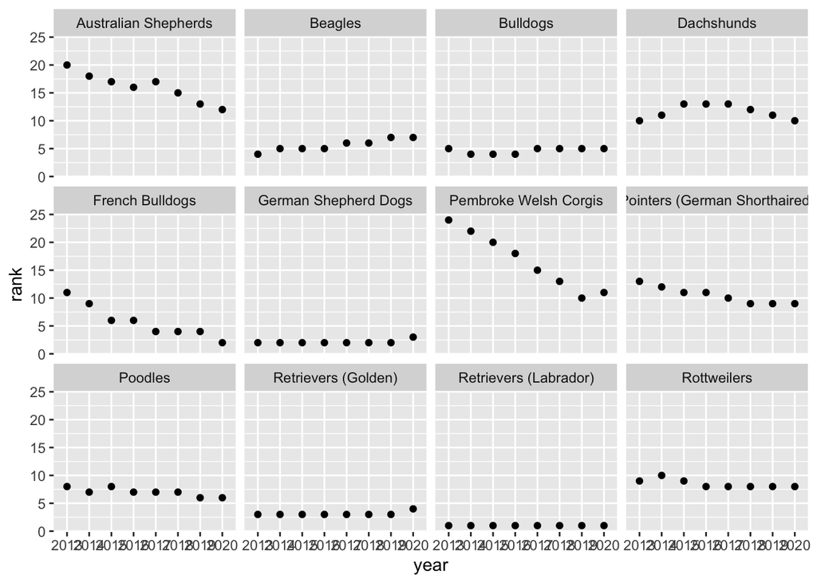

```r
# what dogs should I include?
dogs_to_include <- breed_rank_tidy %>%
  filter(year == 2020 & rank <= 12)

# plot
breed_rank_tidy %>%
  filter(breed %in% dogs_to_include$breed) %>%
  ggplot(aes(x = year, y = rank)) +
    geom_point() +
    facet_wrap(vars(breed))
```

Alter the aesthetics of this plot until you think it looks good.

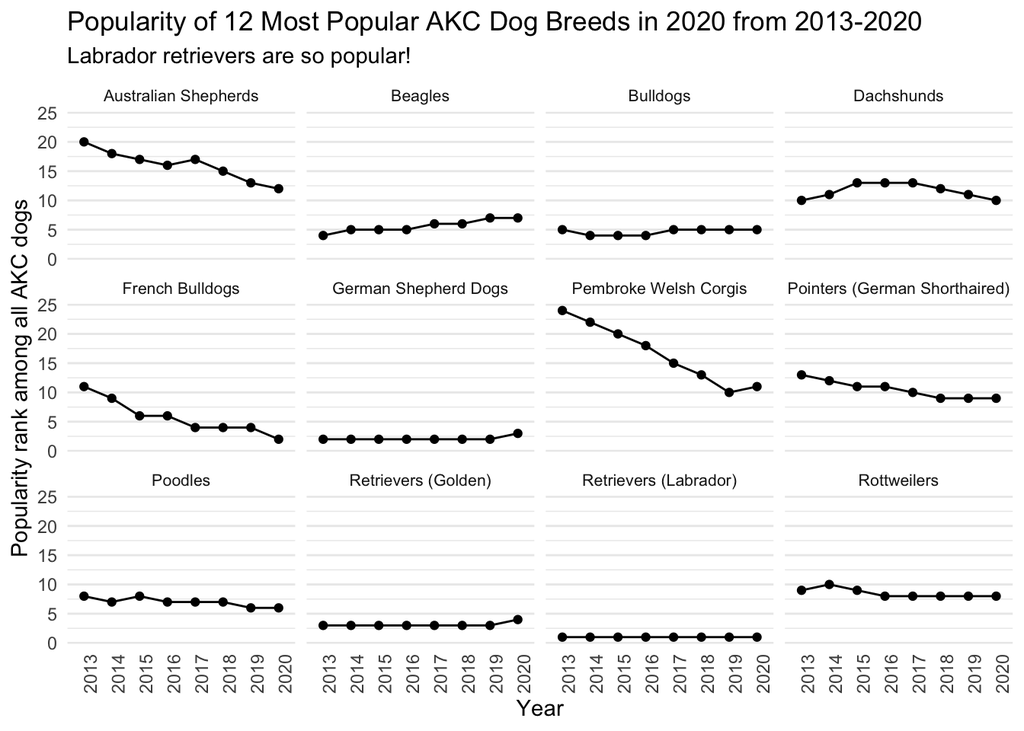

```r
breed_rank_tidy %>%
  filter(breed %in% dogs_to_include$breed) %>%
  ggplot(aes(x = year, y = rank, group = breed)) +
    geom_point() +
    geom_line() +
    facet_wrap(vars(breed)) +
    theme_minimal() +
    theme(axis.text.x = element_text(angle = 90),
          strip.text = element_text(size = 8),
          panel.grid.major.x = element_blank()) +
    labs(x = "Year",
         y = "Popularity rank among all AKC dogs",
         title = "Popularity of 12 Most Popular AKC Dog Breeds in 2020 from 2013-2020",
         subtitle = "Labrador retrievers are so popular!")
```

What dog has jumped in the rankings most from 2013 to 2020? What has dropped the most?

```r
breed_rank %>%
  mutate(rank_inc = (x2020_rank - x2013_rank)) %>%
  select(breed, rank_inc, everything()) %>%
  slice_min(n = 1, order_by = rank_inc) %>%
  select(breed, rank_sum, x2013_rank, x2020_rank)
```

```
## # A tibble: 1 × 4
##   breed             rank_sum x2013_rank x2020_rank
##   <chr>                <dbl>      <dbl>      <dbl>
## 1 Spaniels (Boykin)      821        121         87
```

```r
breed_rank %>%
  mutate(rank_inc = (x2020_rank - x2013_rank)) %>%
  select(breed, rank_inc, everything()) %>%
  slice_max(n = 1, order_by = rank_inc) %>%
  select(breed, rank_sum, x2013_rank, x2020_rank)
```

```
## # A tibble: 1 × 4
##   breed                     rank_sum x2013_rank x2020_rank
##   <chr>                        <dbl>      <dbl>      <dbl>
## 1 Treeing Walker Coonhounds     1019        101        153
```